# **1. EDA**

### As we can see the count of 0's is much higher than 1's. Let's look at a pie chart for better understanding

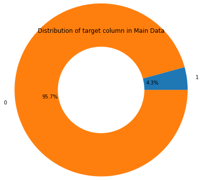

```python
#Now let's check out how the default column in both of our datasets is distributed.
#First our Main Data set
Default=['1', '0']
count=[pie_chart_count[1], pie_chart_count[0]]

plt.title("Distribution of target column in Main Data")
plt.pie(count, labels=Default, radius =2, autopct='%0.1f%%')
plt.pie([1], colors='white', radius = 1)
plt.show()
```

In our main Dataset. 95.7 % of the output is 0 while only 4.3 % output is 1

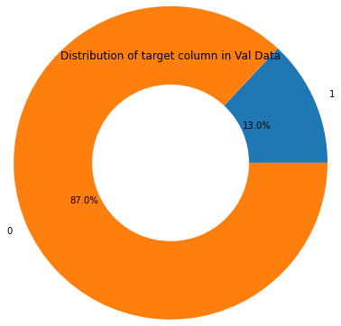

```python
# Now for our validation Dataset
Default=['1', '0']
count=[pie_chart_count_val[1], pie_chart_count_val[0]]

plt.title("Distribution of target column in Val Data")
plt.pie(count, labels=Default, radius =2, autopct='%0.1f%%')
plt.pie([1], colors='white', radius = 1)
plt.show()
```

In our Validation Dataset. 87.0 % of the output is 0 while only 13.0 % output is 1

#### By looking at both the above graphs. We can see that both of our datasets is not equally distribued.

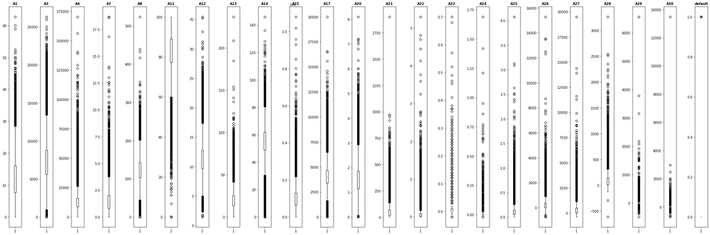

```python
#Now let's try to see if our dataset has any outliers in it.
#Plotting each and every column in each separate graph.

fig, axs = plt.subplots(1, len(data.columns), figsize=(30,10))

for i, ax in enumerate(axs.flat):
    ax.boxplot(data.iloc[:,i])
    ax.set_title(data.columns[i], fontsize=10, fontweight='bold')
    ax.tick_params(axis='y', labelsize=10)

plt.tight_layout()

#Second all in one
#data.plot(kind='box', figsize=(25,10)) #Plots to find the outliers in each column
```

The Above Graph was of our main dataset.

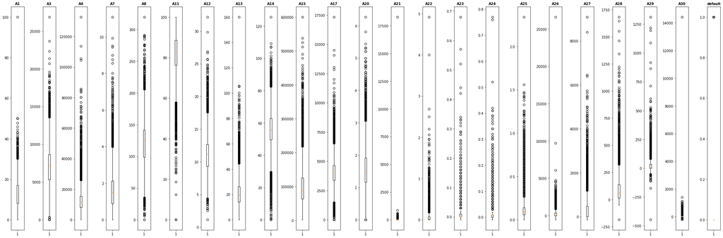

```python
#Having all of them in a separate graphs
fig, axs = plt.subplots(1, len(data_val.columns), figsize=(30,10))

for i, ax in enumerate(axs.flat):
    ax.boxplot(data_val.iloc[:,i])
    ax.set_title(data_val.columns[i], fontsize=10, fontweight='bold')
    ax.tick_params(axis='y', labelsize=10)

plt.tight_layout()
```

The Above graph was for our validation dataset. The outliers exist in both the datasets but there seems to be less outliers in validation dataset.